# TFG Migración y turismo inteligente.

Modelos de IA para análisis y visualización.

# EDA CLUSTERING

En este bloque se va a realizar un análisis exploratorio del dataset filtrado pero enfocado en el modelado de clusters.

El objetivo es entender la estructura de las distintas variables y sus relaciones entre sí, y evaluar aquellas más idoneas para el posterior modelado.

En esta primera fase se procede a cargar el dataset filtrado y a realizar un análisis inicial.

```python
import pandas as pd
import numpy as np
import matplotlib.pyplot as plt
import seaborn as sns
from sklearn.preprocessing import LabelEncoder
import scipy.stats as ss
import itertools
from sklearn.preprocessing import OneHotEncoder, StandardScaler
from sklearn.decomposition import PCA
```

```
Dimensiones del dataset: (15013, 9)

Tipos de datos:
Vía de acceso                      object
Comunidad autónoma de destino      object
Motivo del viaje                   object
Tipo de alojamiento                object
Forma de organización del viaje    object
Duración del viaje                 object
País de residencia                 object
Periodo                            object
Total                               int64
dtype: object
```

|  | Vía de acceso | Comunidad autónoma de destino | Motivo del viaje | Tipo de alojamiento | Forma de organización del viaje | Duración del viaje | País de residencia | Periodo | Total |
| --- | --- | --- | --- | --- | --- | --- | --- | --- | --- |
| 0 | Aeropuerto | 01 Andalucía | Negocios y otros motivos profesionales | De mercado | Con paquete turístico | De 2 a 3 noches | Reino Unido | 2024M07 | 9359 |
| 1 | Aeropuerto | 01 Andalucía | Negocios y otros motivos profesionales | De mercado | Sin paquete turístico | 1 noche | Alemania | 2019M10 | 15859 |
| 2 | Aeropuerto | 01 Andalucía | Negocios y otros motivos profesionales | De mercado | Sin paquete turístico | De 4 a 7 noches | Alemania | 2018M03 | 21097 |

```
Porcentaje de valores nulos por columna:
Vía de acceso                      0.0
Comunidad autónoma de destino      0.0
Motivo del viaje                   0.0
Tipo de alojamiento                0.0
Forma de organización del viaje    0.0
Duración del viaje                 0.0
País de residencia                 0.0
Periodo                            0.0
Total                              0.0
dtype: float64

Valores únicos por variable:
Vía de acceso                          4
Comunidad autónoma de destino         11
Motivo del viaje                       3
Tipo de alojamiento                    6
Forma de organización del viaje        2
Duración del viaje                     5
País de residencia                    30
Periodo                              109
Total                              12216
dtype: int64

Estadísticas descriptivas de la variable Total:
count     15013.000000
mean      28223.745354
std       33226.219055
min          57.000000
25%       10087.000000
50%       17569.000000
75%       32104.000000
max      291866.000000
Name: Total, dtype: float64
```

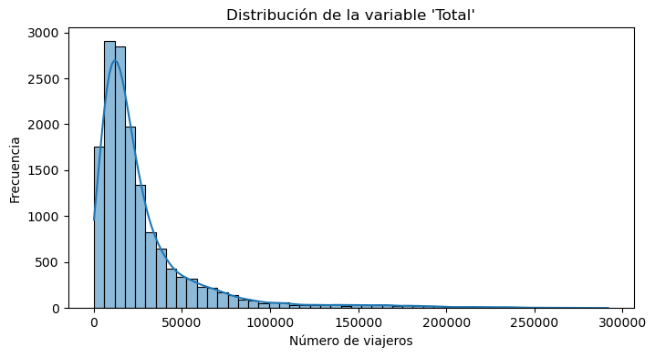

```python
archivo = "13884_filtrado.csv"
df = pd.read_csv(archivo, encoding='utf-8-sig')

print("Dimensiones del dataset:", df.shape)
print("\nTipos de datos:")
print(df.dtypes)

display(df.head(3))

print("\nPorcentaje de valores nulos por columna:")
print(df.isnull().mean().round(4) * 100)

print("\nValores únicos por variable:")
print(df.nunique())

print("\nEstadísticas descriptivas de la variable Total:")
print(df['Total'].describe())

plt.figure(figsize=(8,4))
sns.histplot(df['Total'], bins=50, kde=True)
plt.title("Distribución de la variable 'Total'")
plt.xlabel("Número de viajeros")
plt.ylabel("Frecuencia")
plt.show()
```

Los resultados del análisis previo muestran lo siguiente:

- Como se mencionó en el anterior notebook, el número de filas es de 15013 y 9 columnas.
- No existen nulos en ninguna columna, por lo que el filtrado fue efectivo.
- La distribución de la variable numerica tiene un fuerte sesgo y posiblemente outliers.

```
Vía de acceso
Vía de acceso
Aeropuerto    14415
Puerto          283
Tren            178
Carretera       137
Name: count, dtype: int64
Total de categorías: 4

Comunidad autónoma de destino
Comunidad autónoma de destino
04 Balears, Illes          4084
05 Canarias                3984
09 Cataluña                3298
01 Andalucía               1665
10 Comunitat Valenciana    1397
13 Madrid, Comunidad de     544
14 Murcia, Región de         17
16 País Vasco                12
06 Cantabria                  7
12 Galicia                    4
Name: count, dtype: int64
Total de categorías: 11

Motivo del viaje
Motivo del viaje
Ocio, recreo y vacaciones                 14829
Negocios y otros motivos profesionales      113
Otros motivos                                71
Name: count, dtype: int64
Total de categorías: 3

Tipo de alojamiento
Tipo de alojamiento
De mercado                         8011
Hotelero                           5714
Vivienda en alquiler                748
Vivienda de familiares o amigos     265
Vivienda en propiedad               192
Resto de mercado                     83
```

[output cut: 19 more lines]

```

País de residencia
País de residencia
Reino Unido                  3438
Alemania                     2259
Francia                      1781
Italia                       1421
Países Bajos                 1066
Resto de Europa              1015
Irlanda                       685
Bélgica                       589
Estados Unidos de América     550
Suecia                        449
Name: count, dtype: int64
Total de categorías: 30
```

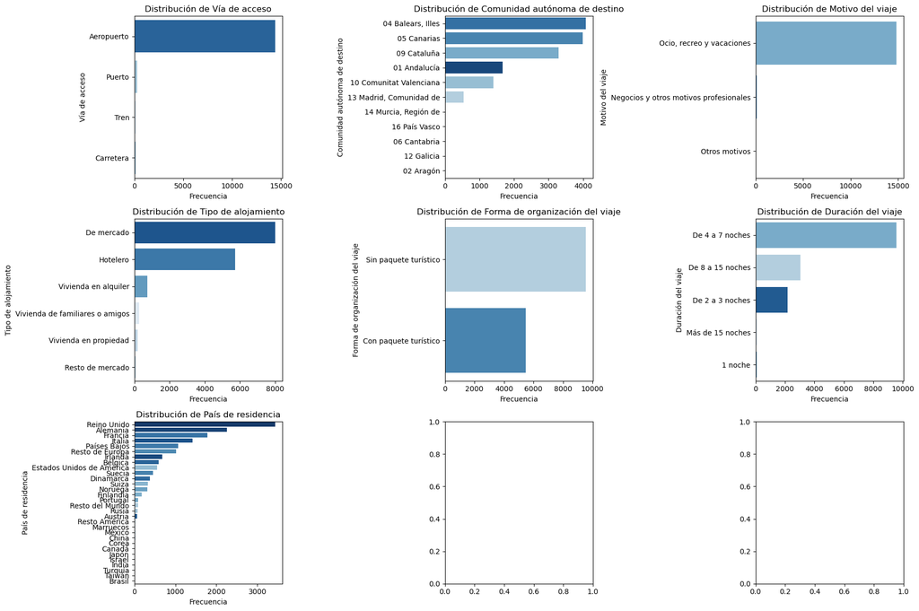

```
Número de combinaciones únicas Comunidad-País: 120
```

|  | Comunidad autónoma de destino | País de residencia | frecuencia |
| --- | --- | --- | --- |
| 0 | 01 Andalucía | Alemania | 215 |
| 1 | 01 Andalucía | Austria | 3 |
| 2 | 01 Andalucía | Bélgica | 66 |
| 3 | 01 Andalucía | Canadá | 2 |
| 4 | 01 Andalucía | Corea | 2 |
| 5 | 01 Andalucía | Dinamarca | 31 |
| 6 | 01 Andalucía | Estados Unidos de América | 4 |
| 7 | 01 Andalucía | Finlandia | 12 |
| 8 | 01 Andalucía | Francia | 276 |
| 9 | 01 Andalucía | Irlanda | 121 |

```python
cat_cols = [
    'Vía de acceso', 'Comunidad autónoma de destino', 'Motivo del viaje',
    'Tipo de alojamiento', 'Forma de organización del viaje',
    'Duración del viaje', 'País de residencia'
]

for col in cat_cols:
    print(f"\n{col}")
    print(df[col].value_counts().head(10))
    print(f"Total de categorías: {df[col].nunique()}")

fig, axes = plt.subplots(3, 3, figsize=(18, 12))
axes = axes.flatten()

for i, col in enumerate(cat_cols):
    sns.countplot(
        y=col,
        data=df,
        order=df[col].value_counts().index,
        hue=col,
        legend=False,
        palette='Blues_r',
        ax=axes[i]
    )
    axes[i].set_title(f"Distribución de {col}")
    axes[i].set_xlabel("Frecuencia")

plt.tight_layout()
plt.show()

tabla_rutas = (
    df.groupby(['Comunidad autónoma de destino', 'País de residencia'])
      .size().reset_index(name='frecuencia')
)
print("\nNúmero de combinaciones únicas Comunidad-País:", len(tabla_rutas))
display(tabla_rutas.head(10))
```

Los resultados muestran lo siguiente:

- Vía de acceso esta sobre representada por la categoría aeropuerto
- Comunidad autónoma de destino tiene una fuerte concentración de Baleares, Canarias y Cataluña.
- Para motivo de viaje, la categoria Ocio es casi única, lo que indica que será poco representativa para el clustering.
- Tipo de alojamiento esta representada principalmente por De mercado y Hotelero.
- Forma de organizacion está mas equilibrado entre las dos categorias posibles.
- La duracion del viaje predomina de 4 a 7 noches.
- Para País de residencia, 5 países copan los primeros puestos.

En el siguiente paso, se van a realizar determinadas transformaciones previas al clustering, como son:

- Agrupar categorias residuales en nueva categoria "Otras".
- Recategorización de Duracion del viaje.
- Eliminar columna motivo del viaje por poca varianza.
- Tranformación logarítmica de la categoria total para evitar sesgo.

Ademas se realiza un análisis de correlacion de Cramer entre las variables categóricas.

**Fuentes**

- Autor desconocido. (s. f.). What is a good cluster analysis method when the variables are right skewed [Pregunta en línea]. Recuperado de https://www.quora.com/What-is-a-good-cluster-analysis-method-when-the-variables-are-right-skewed
- Castaño Cruz, J. S. (2024). Métodos robustos para clustering de series de tiempo (Tesis de Licenciatura, Facultad de Ciencias Exactas y Naturales, Universidad de Buenos Aires). Recuperado de https://web.dm.uba.ar/files/tesis_lic/2024/Cruz.pdf
- Gallardo-San Salvador, J. A. (1994). Introducción al análisis cluster. Consideraciones generales [Documento PDF]. Universidad de Granada. Recuperado de https://www.ugr.es/~gallardo/pdf/cluster-g.pdf
- Postance, B. (2021, abril 19). A guide to clustering large datasets with mixed data-types [Artículo de blog]. Recuperado de https://bpostance.github.io/posts/clustering-mixed-data/?_x_tr_sl=en&_x_tr_tl=es&_x_tr_hl=es&_x_tr_pto=tc

```python
df_prep = df.copy()

df_prep['Vía de acceso'] = np.where(df_prep['Vía de acceso'] == 'Aeropuerto', 'Aeropuerto', 'Otros')
df_prep['Motivo del viaje'] = 'Ocio'  # Prácticamente constante, se descarta después

freq_ccaa = df_prep['Comunidad autónoma de destino'].value_counts(normalize=True)
ccaa_bajas = freq_ccaa[freq_ccaa < 0.01].index
df_prep['Comunidad autónoma de destino'] = df_prep['Comunidad autónoma de destino'].replace(ccaa_bajas, 'Otras')

freq_pais = df_prep['País de residencia'].value_counts(normalize=True)
paises_bajos = freq_pais[freq_pais < 0.01].index
df_prep['País de residencia'] = df_prep['País de residencia'].replace(paises_bajos, 'Otros')

orden_duracion = {
    '1 noche': 1,
    'De 2 a 3 noches': 2,
    'De 4 a 7 noches': 3,
    'De 8 a 15 noches': 4,
    'Más de 15 noches': 5
}
df_prep['Duración codificada'] = df_prep['Duración del viaje'].map(orden_duracion)

df_prep['Total_log'] = np.log1p(df_prep['Total'])

def cramers_v(x, y):
    confusion_matrix = pd.crosstab(x, y)
    chi2 = ss.chi2_contingency(confusion_matrix)[0]
    n = confusion_matrix.sum().sum()
    phi2 = chi2 / n
    r, k = confusion_matrix.shape
    phi2corr = max(0, phi2 - ((k - 1)*(r - 1)) / (n - 1))
    rcorr = r - ((r - 1)**2) / (n - 1)
    kcorr = k - ((k - 1)**2) / (n - 1)
    return np.sqrt(phi2corr / min((kcorr - 1), (rcorr - 1)))

cat_vars = [
    'Vía de acceso', 'Comunidad autónoma de destino', 'Tipo de alojamiento',
    'Forma de organización del viaje', 'País de residencia'
]

matriz_cramer = pd.DataFrame(index=cat_vars, columns=cat_vars)

for v1, v2 in itertools.combinations(cat_vars, 2):
    val = cramers_v(df_prep[v1], df_prep[v2])
    matriz_cramer.loc[v1, v2] = round(val, 3)
    matriz_cramer.loc[v2, v1] = round(val, 3)

print("Matriz de asociación Cramer’s V (0–1):")
display(matriz_cramer)
```

```
Matriz de asociación Cramer’s V (0–1):
```

|  | Vía de acceso | Comunidad autónoma de destino | Tipo de alojamiento | Forma de organización del viaje | País de residencia |
| --- | --- | --- | --- | --- | --- |
| Vía de acceso | NaN | 0.287 | 0.031 | 0.044 | 0.343 |
| Comunidad autónoma de destino | 0.287 | NaN | 0.157 | 0.446 | 0.24 |
| Tipo de alojamiento | 0.031 | 0.157 | NaN | 0.25 | 0.102 |
| Forma de organización del viaje | 0.044 | 0.446 | 0.25 | NaN | 0.267 |
| País de residencia | 0.343 | 0.24 | 0.102 | 0.267 | NaN |

Los resultados no muestran ninguna correlacion fuerte (>0.6) entre ninguna variable por lo que no se detecta multicolinealidad.

Algunas referencias son:

- Comunidad y forma de organizacion si tiene una correlación moderada, lo que se puede interpretar como que las comunidades turisticas se contratan mas con paquetes.
- Via de acceso con Comunidad y con Pais tienen correlaciones moderadas, pero estaba sobre representada por Aeropuerto, lo que tiene sentido en ambos casos.
- Tipo de alojamiento y Forma de organizacion tienen correlación moderada. Un paquete turistico suele tener asociado el hotel.

En el siguiente paso, seleccionamos las variables finales para el clustering, realizamos un analísis de componentes principales (PCA) para detectar separaciones entre grupos y crearemos un dataset para el modelado de clusters.

```
Dataset numérico listo para clustering: (15013, 34)
```

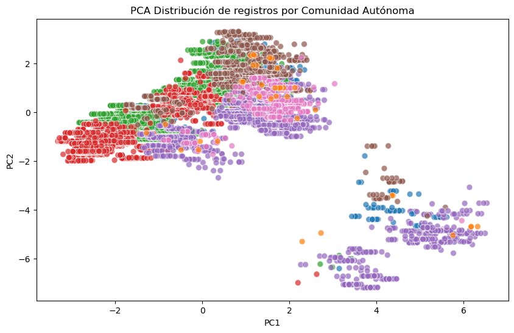

```
Archivo guardado como df_clustering.csv
```

```python
vars_finales = [
    'Comunidad autónoma de destino', 'País de residencia',
    'Vía de acceso', 'Tipo de alojamiento',
    'Forma de organización del viaje', 'Duración codificada', 'Total_log'
]
df_final = df_prep[vars_finales].copy()

cat_vars = [
    'Comunidad autónoma de destino', 'País de residencia',
    'Vía de acceso', 'Tipo de alojamiento', 'Forma de organización del viaje'
]

encoder = OneHotEncoder(sparse_output=False)
encoded = encoder.fit_transform(df_final[cat_vars])
encoded_cols = encoder.get_feature_names_out(cat_vars)

df_encoded = pd.DataFrame(encoded, columns=encoded_cols, index=df_final.index)

df_cluster_ready = pd.concat([
    df_encoded,
    df_final[['Duración codificada', 'Total_log']]
], axis=1)

print("Dataset numérico listo para clustering:", df_cluster_ready.shape)

scaler = StandardScaler()
df_scaled = scaler.fit_transform(df_cluster_ready)

pca = PCA(n_components=2, random_state=42)
pca_result = pca.fit_transform(df_scaled)

pca_df = pd.DataFrame(pca_result, columns=['PC1', 'PC2'])
pca_df['Comunidad'] = df_prep['Comunidad autónoma de destino']
pca_df['País'] = df_prep['País de residencia']

plt.figure(figsize=(10, 6))
sns.scatterplot(data=pca_df, x='PC1', y='PC2', hue='Comunidad', alpha=0.7, s=50, legend=False)
plt.title("PCA Distribución de registros por Comunidad Autónoma")
plt.show()

df_cluster_ready.to_csv("df_clustering.csv", index=False, encoding='utf-8-sig')
print("Archivo guardado como df_clustering.csv")
```

La representación sugiere varios grupos visibles, con dos zonas separadas y nubes internas.

```python
import joblib

joblib.dump({
    "df_cluster_ready": df_cluster_ready,
    "df_prep": df_prep,
    "df_scaled": df_scaled,
    "pca_df": pca_df,
    "scaler": scaler,
    "encoder": encoder
}, "clustering_preprocesado.pkl")

print("Archivo clustering_preprocesado.pkl guardado")
```

```
Archivo clustering_preprocesado.pkl guardado
```